# Intro

## 10.3 Backtesting

### 10.3.1 Trade for every `lg_inc` classfication

We might want to know: How much profit/loss would we have realized if we had placed trades whenever the model classified a large increase, i.e. `lg_inc`. For this purpose, we make the following simplifying assumptions.

- Commission per trade: 0 USD
- Cash in portfolio: enough to place any trade
- Percent of portfolio that is used for 1 trade: 10% (i.e. 2K USD)
- Percentage of tickers that are tradable: 100%
- Percentage of trades that are executed fully: 100%
- Max. loss of 1 trade: 5% (i.e. 100 USD)
- Max. percentage change realized in case of increase: 50%

Note that the latter assumption is because some proportion of the percentage change might have taken place before we can enter the trade (e.g. pre-market outside of the market trading hours). Further note that the "max. loss of 1 trade" assumption reflects a stop loss. It assumes that we would and can cut our losses on a trade short - if the percentage change is negative.

```python
df_sub = df_te
df_sub.loc[:, "pred"] = pred
df_sub = df_sub[df_sub["pred"] == "lg_inc"]
```

```python
profit_trades = (df_sub[df_sub["Y_cont"] > 0].Y_cont * 2000 * 0.5)
print("The {} profitable trades would have resulted in {} USD profit".format(len(profit_trades), round(profit_trades.sum())))

loss_trades = np.maximum(df_sub[df_sub["Y_cont"] < 0].Y_cont, -0.05) * 2000
print("The {} non-profitable trades would have resulted in {} USD loss".format(len(loss_trades), round(loss_trades.sum())))

print("In total, we would have achieved a profit of {} USD".format(round(profit_trades.sum() + loss_trades.sum())))
```

```
The 898 profitable trades would have resulted in 52002.0 USD profit
The 728 non-profitable trades would have resulted in -43205.0 USD loss
In total, we would have achieved a profit of 8797.0 USD
```

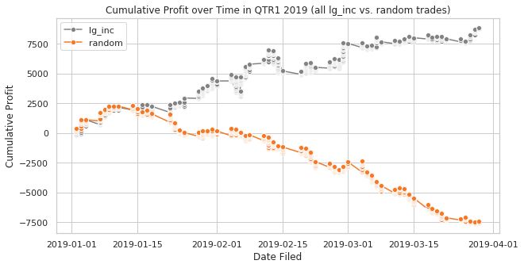

```python
# Line Plot: Cumulative Profit over Time
df_sub = df_te.copy()
df_sub = df_sub[df_sub["pred"] == "lg_inc"]
df_sub.loc[:, "result"] = 0
df_sub.loc[df_sub["Y_cont"] > 0, "result"] = df_sub[df_sub["Y_cont"] > 0].Y_cont * 2000 * 0.5
df_sub.loc[df_sub["Y_cont"] < 0, "result"] = np.maximum(df_sub[df_sub["Y_cont"] < 0].Y_cont, -0.05) * 2000
df_sub.loc[:, "Date Filed"] = pd.to_datetime(df_sub.loc[:, "Date Filed"])
df_sub = df_sub.sort_values("Date Filed")
df_sub.loc[:, "result_cumulative"] = df_sub.loc[:, "result"].cumsum()

df_ran = df_te.sample(n = len(df_sub), random_state = 1)
df_ran.loc[:, "result"] = 0
df_ran.loc[df_ran["Y_cont"] > 0, "result"] = df_ran[df_ran["Y_cont"] > 0].Y_cont * 2000 * 0.5
df_ran.loc[df_ran["Y_cont"] < 0, "result"] = np.maximum(df_ran[df_ran["Y_cont"] < 0].Y_cont, -0.05) * 2000
df_ran.loc[:, "Date Filed"] = pd.to_datetime(df_ran.loc[:, "Date Filed"])
df_ran = df_ran.sort_values("Date Filed")
df_ran.loc[:, "result_cumulative"] = df_ran.loc[:, "result"].cumsum()

sns.set_style("whitegrid")
plt.rcParams["figure.figsize"] = [10,5]
fig, ax = plt.subplots()
sns.lineplot(x = "Date Filed", y = "result_cumulative", data = df_sub,
             marker = "o", estimator = None, ax = ax, label = "lg_inc",
             color = sns.color_palette("Greys").as_hex()[3])
sns.lineplot(x = "Date Filed", y = "result_cumulative", data = df_ran,
             marker = "o", estimator = None, ax = ax, label = "random",
             color = sns.color_palette("Oranges").as_hex()[3])
ax.set(ylabel = "Cumulative Profit",
       title = "Cumulative Profit over Time in QTR1 2019 (all lg_inc vs. random trades)")
ax.legend()
plt.show(fig)

fig.savefig("{}/figures/trade_lg_inc_all.png".format(base_path),
            bbox_inches = "tight")
```

### 10.3.1 Trade for `lg_inc` classfications with high probabiliy

Instead of placing a trade whenever `lg_inc` is classified, we place a trade when a certain threshold for the probability of this trade is met.

```python
prob = best_model.predict(data, prediction_type = "Probability")
print(prob.shape)
df_prob = pd.DataFrame(prob)
df_prob.columns = best_model.classes_
df_prob.head()
```

```
(7975, 5)
```

|  | lg_dec | lg_inc | same | sm_dec | sm_inc |
| --- | --- | --- | --- | --- | --- |
| 0 | 0.403819 | 0.289312 | 0.074005 | 0.128510 | 0.104356 |
| 1 | 0.182805 | 0.138487 | 0.250754 | 0.203940 | 0.224015 |
| 2 | 0.309153 | 0.358631 | 0.076737 | 0.144720 | 0.110759 |
| 3 | 0.174007 | 0.143138 | 0.253900 | 0.228154 | 0.200802 |
| 4 | 0.310735 | 0.234933 | 0.119641 | 0.149829 | 0.184862 |

```python
# Check that order matches
display(pd.crosstab(index = df_prob.idxmax(axis=1), columns = "cnt"))
display(pd.crosstab(index = pred, columns = "cnt"))
```

| col_0 row_0 | cnt |
| --- | --- |
| lg_dec | 1441 |
| lg_inc | 1627 |
| same | 2182 |
| sm_dec | 1267 |
| sm_inc | 1458 |

| col_0 row_0 | cnt |
| --- | --- |
| lg_dec | 1441 |
| lg_inc | 1627 |
| same | 2182 |
| sm_dec | 1267 |
| sm_inc | 1458 |

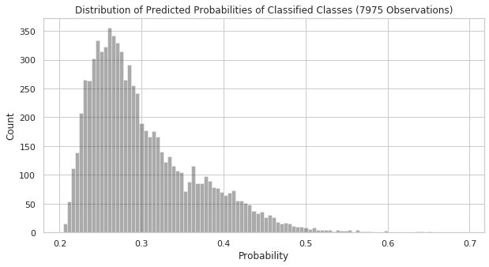

```python
# Check distribution of number of tokens per filing.

%matplotlib inline
plt.rcParams["figure.figsize"] = [10,5]
p = sns.distplot(a = df_prob.max(axis=1), bins = 100, norm_hist = False, kde=False,
                  color = sns.color_palette("Greys").as_hex()[5])
plt.title("Distribution of Predicted Probabilities of Classified Classes ({} Observations)".format(len(df_prob.max(axis=1))))
plt.ylabel("Count")
plt.xlabel("Probability")
plt.show(p)

plt.show(p);
fig = p.get_figure()
fig.savefig("{}/figures/dist_pred_prob.png".format(base_path),
             bbox_inches = "tight")
```

```python
df_sub = df_te.copy()
df_sub["pred"] = pred
df_sub["prob"] = df_prob.max(axis=1)
df_sub = df_sub[(df_sub["pred"] == "lg_inc") & (df_sub["prob"] > 0.4)]
```

```python
profit_trades = (df_sub[df_sub["Y_cont"] > 0].Y_cont * 2000 * 0.5)
print("The {} profitable trades would have resulted in {} USD profit".format(len(profit_trades), round(profit_trades.sum())))

loss_trades = np.maximum(df_sub[df_sub["Y_cont"] < 0].Y_cont, -0.05) * 2000
print("The {} non-profitable trades would have resulted in {} USD loss".format(len(loss_trades), round(loss_trades.sum())))

print("In total, we would have achieved a profit of {} USD".format(round(profit_trades.sum() + loss_trades.sum())))
```

```
The 273 profitable trades would have resulted in 18949.0 USD profit
The 170 non-profitable trades would have resulted in -11499.0 USD loss
In total, we would have achieved a profit of 7450.0 USD
```

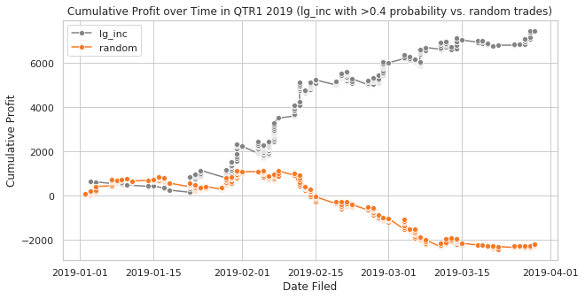

```python
# Line Plot: Cumulative Profit over Time
df_sub = df_te.copy()
df_sub["pred"] = pred
df_sub["prob"] = df_prob.max(axis=1)
df_sub = df_sub[(df_sub["pred"] == "lg_inc") & (df_sub["prob"] > 0.40)]

df_sub.loc[:, "result"] = 0
df_sub.loc[df_sub["Y_cont"] > 0, "result"] = df_sub[df_sub["Y_cont"] > 0].Y_cont * 2000 * 0.5
df_sub.loc[df_sub["Y_cont"] < 0, "result"] = np.maximum(df_sub[df_sub["Y_cont"] < 0].Y_cont, -0.05) * 2000
df_sub.loc[:, "Date Filed"] = pd.to_datetime(df_sub.loc[:, "Date Filed"])
df_sub = df_sub.sort_values("Date Filed")
df_sub.loc[:, "result_cumulative"] = df_sub.loc[:, "result"].cumsum()

df_ran = df_te.sample(n = len(df_sub), random_state = 1)
df_ran.loc[:, "result"] = 0
df_ran.loc[df_ran["Y_cont"] > 0, "result"] = df_ran[df_ran["Y_cont"] > 0].Y_cont * 2000 * 0.5
df_ran.loc[df_ran["Y_cont"] < 0, "result"] = np.maximum(df_ran[df_ran["Y_cont"] < 0].Y_cont, -0.05) * 2000
df_ran.loc[:, "Date Filed"] = pd.to_datetime(df_ran.loc[:, "Date Filed"])
df_ran = df_ran.sort_values("Date Filed")
df_ran.loc[:, "result_cumulative"] = df_ran.loc[:, "result"].cumsum()

sns.set_style("whitegrid")
plt.rcParams["figure.figsize"] = [10,5]
fig, ax = plt.subplots()
sns.lineplot(x = "Date Filed", y = "result_cumulative", data = df_sub,
             marker = "o", estimator = None, ax = ax, label = "lg_inc",
             color = sns.color_palette("Greys").as_hex()[3])
sns.lineplot(x = "Date Filed", y = "result_cumulative", data = df_ran,
             marker = "o", estimator = None, ax = ax, label = "random",
             color = sns.color_palette("Oranges").as_hex()[3])
ax.set(ylabel = "Cumulative Profit",
       title = "Cumulative Profit over Time in QTR1 2019 (lg_inc with >0.4 probability vs. random trades)")
ax.legend()
plt.show(fig)

fig.savefig("{}/figures/trade_lg_inc_0.4.png".format(base_path),
            bbox_inches = "tight")
```